# Lab 5

R4L

2/13/2019

## Team

### Plot

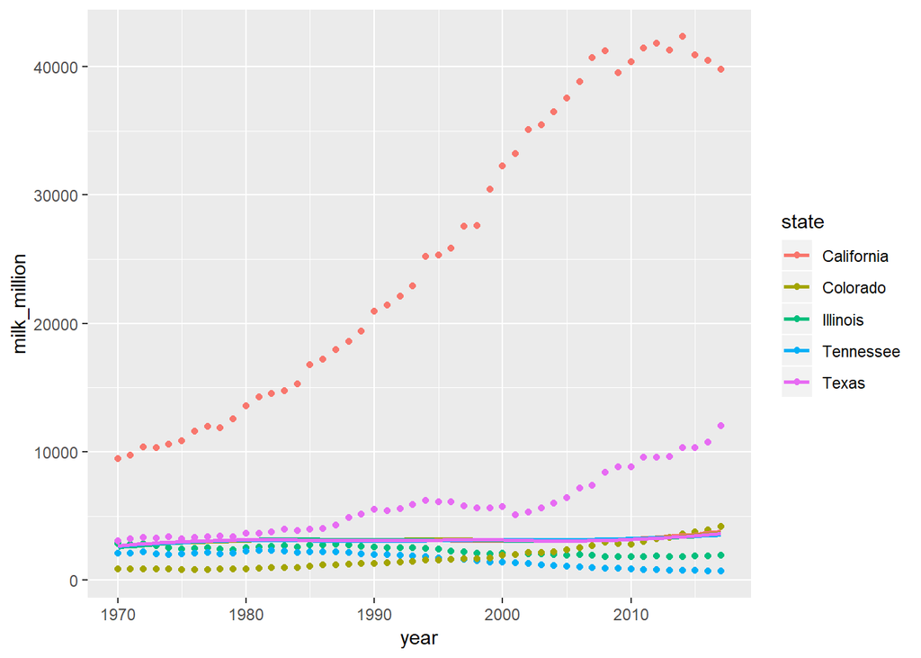

```r
ggplot(data = team_milk, aes(x = year, y = milk_million, color =state))+
  geom_point()+
  geom_smooth(aes(x = year, y = average), se = FALSE)
```

### The year when the most milk was produced in the United States.

The year when the most milk produced was in 2017 with production 4309.32 million lb.

```r
arrange(national, milk) %>%
  top_n(1)
```

```
## # A tibble: 1 x 2
##    year  milk
##   <dbl> <dbl>
## 1  2017 4309.
```

### The year when the least milk was produced in the United States.

The year when the least milk produced was in 1975 with production 2307.96 million lb.

```r
descnational <- national %>%
  mutate(avg = -milk) %>%
  arrange(-milk)

top_n(descnational,1)%>%
  select(year, milk)
```

```
## # A tibble: 1 x 2
##    year  milk
##   <dbl> <dbl>
## 1  1975 2308.
```

### In 2017, report the 5 states that produced the most milk.

```r
filter(team_milk, year == 2017) %>%
  arrange(desc(milk_million))
```

```
##            region      state year milk_produced milk_million average
## 1         Pacific California 2017    3.9798e+10        39798 4309.32
## 2 Southern Plains      Texas 2017    1.2054e+10        12054 4171.94
## 3        Mountain   Colorado 2017    4.1890e+09         4189 4248.12
## 4       Corn Belt   Illinois 2017    1.9290e+09         1929 4024.60
## 5     Appalachian  Tennessee 2017    6.9300e+08          693 4121.12
```

### In 2017, report the 5 states that produced the least milk.

The 5 states that produced the least milk in 2017 was Tennessee with production 693 million lb.

```r
filter(team_milk, year == 2017) %>%
  arrange(milk_million)
```

```
##            region      state year milk_produced milk_million average
## 1     Appalachian  Tennessee 2017    6.9300e+08          693 4121.12
## 2       Corn Belt   Illinois 2017    1.9290e+09         1929 4024.60
## 3        Mountain   Colorado 2017    4.1890e+09         4189 4248.12
## 4 Southern Plains      Texas 2017    1.2054e+10        12054 4171.94
## 5         Pacific California 2017    3.9798e+10        39798 4309.32
```

### Team Summary

In this project, our team learns how to use the data transformation to process data, for helping us to read the data much easier. By using data transformation, for example, filter() function helping us to ignore the unwanted data, and we can make a more accurate plot. Furthermore, we use summarise() function to calculate the average milk produced and median milk produced, and we find there is a huge difference between average and median. Therefore, analyze data by using data transformation is the most helpful things we learn by this work.

### Yen-Ting Shen

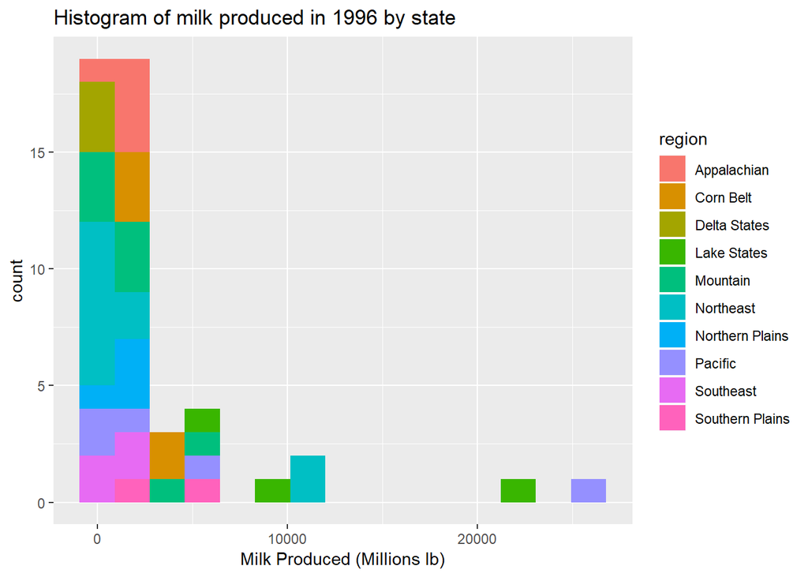

```r
milk1996 <- milk %>%
  filter(year == 1996)

ggplot(data= milk1996, aes(milk_million, fill = region), position = "fill")+
  geom_histogram(bins = 15)+
  ggtitle('Histogram of milk produced in 1996 by state')+
  xlab('Milk Produced (Millions lb)')
```

#### Report

The average milk produced in 1996 was 3080.12 million lb, and the median was 1480 million lb.

```r
milk1996 %>%
  summarise(avg_milk_produced = mean(milk_million), median_milk_produced = median(milk_million))%>%
  arrange(desc(avg_milk_produced))
```

```
##   avg_milk_produced median_milk_produced
## 1           3080.12                 1480
```

The state that produced the most milk in 1996 was California, which they produced 25,848 million lb.

```r
arrange(milk1996, desc(milk_million))%>%
  top_n(1)
```

```
##    region      state year milk_produced milk_million
## 1 Pacific California 1996    2.5848e+10        25848
```

The state that produced the least milk in 1996 was Alaska, which they produces 14 million lb.

```r
# descmilkyen <- milk1996 %>%
#   mutate(milkrank = -milk_million) %>%
#   arrange(-milk_million)
arrange(milk1996, milk_million)%>%
  slice(1)
```

```
##    region  state year milk_produced milk_million
## 1 Pacific Alaska 1996       1.4e+07           14
```

### Emery Schattinger

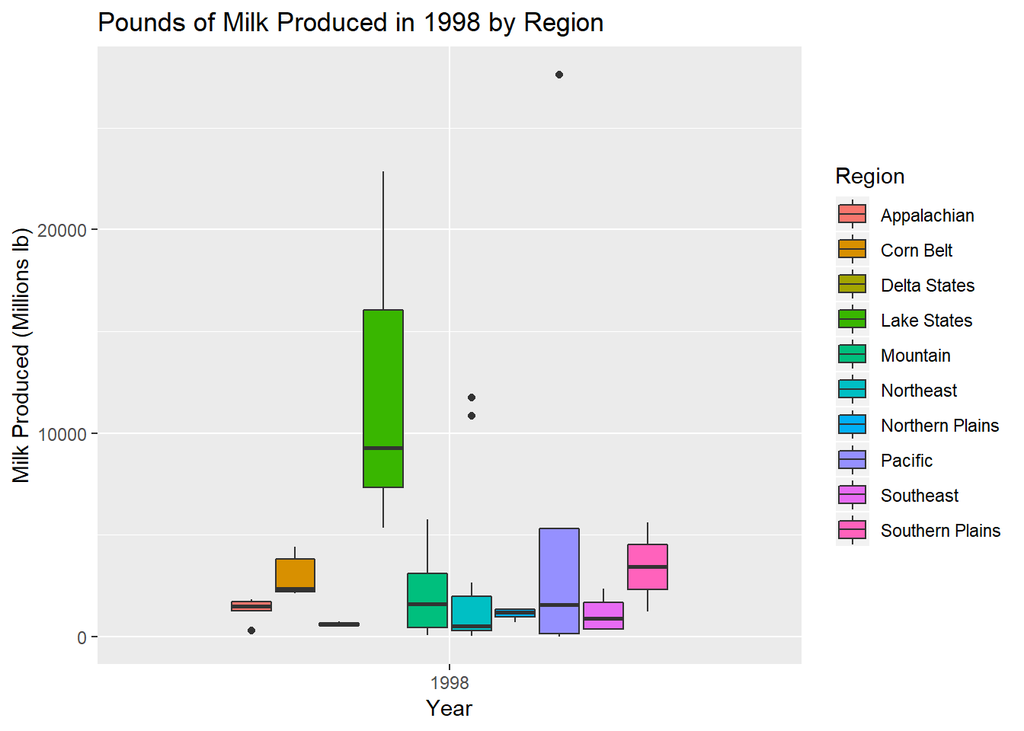

```r
milk1998 <- milk %>%
  filter(year == 1998)

ggplot(data = milk1998, aes(x = as.factor(year), y = milk_million, fill = region)) +  geom_boxplot() +
  ggtitle('Pounds of Milk Produced in 1998 by Region') +
  scale_fill_discrete(name = 'Region') +
  xlab('Year') +
  ylab('Milk Produced (Millions lb)')
```

#### Report

The average milk produced in 1998 was 3145.22 million lb, and the median was 1411.5 million lb.

```r
milk1998 %>%
  filter(year == 1998) %>%
  summarise(avg_milk_produced = mean(milk_million),
            median_milk_produced = median(milk_million))%>%
  arrange(desc(avg_milk_produced))
```

```
##   avg_milk_produced median_milk_produced
## 1           3145.22               1411.5
```

The state that produced the most milk in 1998 was California, which they produced 27,620 million lb.

```r
arrange(milk1998, desc(milk_million))%>%
  top_n(1)
```

```
##    region      state year milk_produced milk_million
## 1 Pacific California 1998     2.762e+10        27620
```

The state that produced the least milk in 1998 was Alaska, which they produces 14 million lb.

```r
leastmilk <- milk1998 %>%
  mutate(milkrank = -milk_million) %>%
  arrange(-milk_million)

top_n(leastmilk,1)%>%
  select(region, state, year, milk_produced, milk_million)
```

```
##    region  state year milk_produced milk_million
## 1 Pacific Alaska 1998       1.4e+07           14
```

### Jason Giblin

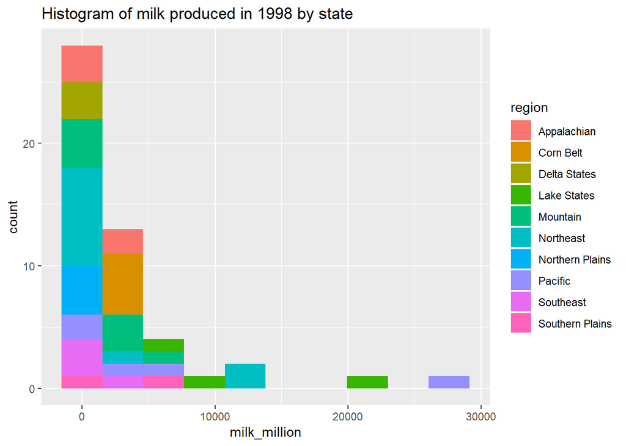

```r
milk1998 <- milk %>%
  filter(year == 1998)

ggplot(data= milk1998, aes(milk_million, fill = region), position = "fill")+
  geom_histogram(bins = 10)+
  ggtitle('Histogram of milk produced in 1998 by state')
```

#### Report

```r
milk1998 %>%
  summarise(avg_milk_produced = mean(milk_million), median_milk_produced = median(milk_million))%>%
  arrange(desc(avg_milk_produced))
```

```
##   avg_milk_produced median_milk_produced
## 1           3145.22               1411.5
```

```r
arrange(milk1998, desc(milk_million)) %>%
   top_n(1)
```

```
##    region      state year milk_produced milk_million
## 1 Pacific California 1998     2.762e+10        27620
```

```r
arrange(milk1998, milk_million) %>%
   slice(1)
```

```
##    region  state year milk_produced milk_million
## 1 Pacific Alaska 1998       1.4e+07           14
```

### Tiger Su

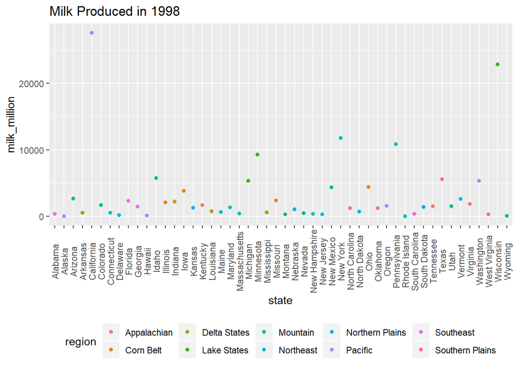

```r
milk1998<- milk%>%

  filter(year==1998)

ggplot(data = milk1998)+

  geom_point(aes(x=state, y=milk_million,color=region))+

  theme(legend.position = "bottom")+

  theme(axis.text.x = element_text(angle = 90, hjust = 0.5, vjust = 0.5))+

  ggtitle('Milk Produced in 1998')
```

#### Report

```r
milk1998%>%

summarise(Average_Milk_Produced_1998=mean(milk_million))
```

```
##   Average_Milk_Produced_1998
## 1                    3145.22
```

```r
milk1998%>%

summarise(Median_of_Milk_Produced_1998=median(milk_million))
```

```
##   Median_of_Milk_Produced_1998
## 1                       1411.5
```

```r
milk1998%>%

arrange(desc(milk_million))%>%

  slice(1)
```

```
##    region      state year milk_produced milk_million
## 1 Pacific California 1998     2.762e+10        27620
```

```r
milk1998%>%

arrange(milk_million)%>%

  slice(1)
```

```
##    region  state year milk_produced milk_million
## 1 Pacific Alaska 1998       1.4e+07           14
```

```r
library(tidyverse)
milk <- read.csv('state_milk_production.csv')
head(milk)
```

```
##      region         state year milk_produced
## 1 Northeast         Maine 1970      6.19e+08
## 2 Northeast New Hampshire 1970      3.56e+08
## 3 Northeast       Vermont 1970      1.97e+09
## 4 Northeast Massachusetts 1970      6.58e+08
## 5 Northeast  Rhode Island 1970      7.50e+07
## 6 Northeast   Connecticut 1970      6.61e+08
```

```r
milk <- milk %>%
  mutate(milk_million = milk_produced/1000000)
```

### Baiyu Chen’s Part:

I make a histogram to show each states’s milk production in 1994. Then, the average milk produced by each state is 3072.04 million of pounds, the median milk produced by each states is 1513 million of pounds. Finally, California produced the most milk which is 25234 million of pounds, and Alaska produced the least amount of milk which is 13.

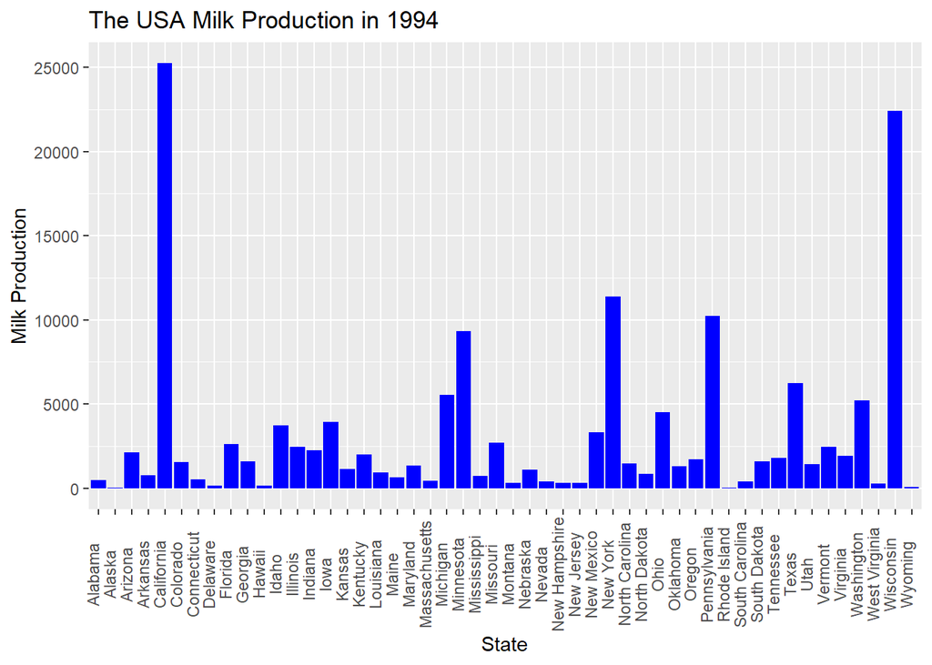

```r
milk1994 <- milk %>%
  filter(year == 1994)

ggplot(data=milk1994)+
         geom_histogram(mapping = aes(x=state, y = milk_million), fill = "blue", stat = "identity")+
theme(axis.text.x=element_text(angle=90,
vjust = 0))+
  ggtitle("The USA Milk Production in 1994")+
  ylab("Milk Production")+
  xlab("State")
```

```r
summarise(milk1994, Average_Milk_Produced  = mean(milk_million, na.rm = TRUE), Median_Milk_Produced = median(milk_million, na.rm = TRUE))
```

```
##   Average_Milk_Produced Median_Milk_Produced
## 1               3072.04                 1513
```

```r
arrange(milk1994, desc(milk_million))%>%
  summarize(Most_Milk=first(milk_million), Most_Milk_state=first(state), Least_Milk=last(milk_million), Least_Milk_State=last(state))
```

```
##   Most_Milk Most_Milk_state Least_Milk Least_Milk_State
## 1     25234      California         13           Alaska
```

## Team

### Plot

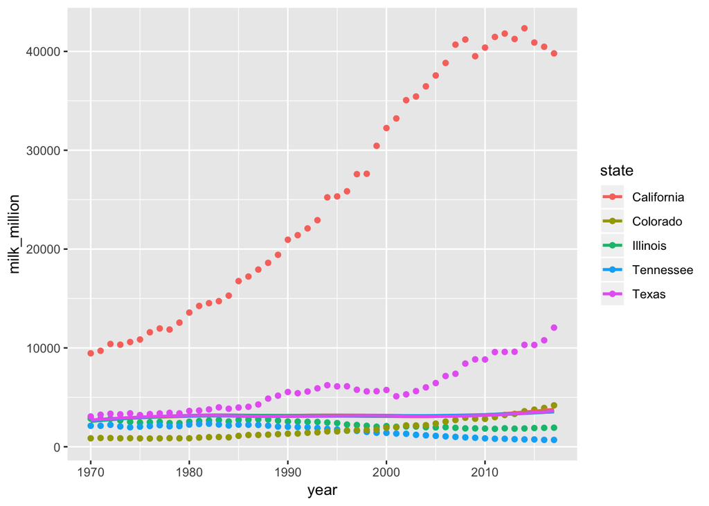

```r
ggplot(data = team_milk, aes(x = year, y = milk_million, color =state))+
  geom_point()+
  geom_smooth(aes(x = year, y = average), se = FALSE)
```

### The year when the most milk was produced in the United States.

The year when the most milk produced was in 2017 with production 4309.32 million lb.

```r
arrange(national, milk) %>%
  top_n(1)
```

```
## # A tibble: 1 x 2
##    year  milk
##   <dbl> <dbl>
## 1  2017 4309.
```

### The year when the least milk was produced in the United States.

The year when the least milk produced was in 1975 with production 2307.96 million lb.

```r
descnational <- national %>%
  mutate(avg = -milk) %>%
  arrange(-milk)

top_n(descnational,1)%>%
  select(year, milk)
```

```
## # A tibble: 1 x 2
##    year  milk
##   <dbl> <dbl>
## 1  1975 2308.
```

### In 2017, report the 5 states that produced the most milk.

```r
filter(team_milk, year == 2017) %>%
  arrange(desc(milk_million))
```

```
##            region      state year milk_produced milk_million average
## 1         Pacific California 2017    3.9798e+10        39798 4309.32
## 2 Southern Plains      Texas 2017    1.2054e+10        12054 4171.94
## 3        Mountain   Colorado 2017    4.1890e+09         4189 4248.12
## 4       Corn Belt   Illinois 2017    1.9290e+09         1929 4024.60
## 5     Appalachian  Tennessee 2017    6.9300e+08          693 4121.12
```

### In 2017, report the 5 states that produced the least milk.

The 5 states that produced the least milk in 2017 was Tennessee with production 693 million lb.

```r
filter(team_milk, year == 2017) %>%
  arrange(milk_million)
```

```
##            region      state year milk_produced milk_million average
## 1     Appalachian  Tennessee 2017    6.9300e+08          693 4121.12
## 2       Corn Belt   Illinois 2017    1.9290e+09         1929 4024.60
## 3        Mountain   Colorado 2017    4.1890e+09         4189 4248.12
## 4 Southern Plains      Texas 2017    1.2054e+10        12054 4171.94
## 5         Pacific California 2017    3.9798e+10        39798 4309.32
```

## Individual

### Yen-Ting Shen

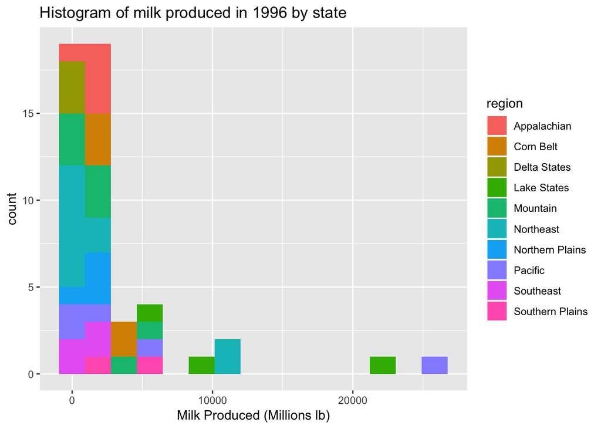

```r
milk1996 <- milk %>%
  filter(year == 1996)

ggplot(data= milk1996, aes(milk_million, fill = region), position = "fill")+
  geom_histogram(bins = 15)+
  ggtitle('Histogram of milk produced in 1996 by state')+
  xlab('Milk Produced (Millions lb)')
```

#### Report

The average milk produced in 1996 was 3080.12 million lb, and the median was 1480 million lb.

```r
milk1996 %>%
  summarise(avg_milk_produced = mean(milk_million), median_milk_produced = median(milk_million))%>%
  arrange(desc(avg_milk_produced))
```

```
##   avg_milk_produced median_milk_produced
## 1           3080.12                 1480
```

The state that produced the most milk in 1996 was California, which they produced 25,848 million lb.

```r
arrange(milk1996, desc(milk_million))%>%
  top_n(1)
```

```
##    region      state year milk_produced milk_million
## 1 Pacific California 1996    2.5848e+10        25848
```

The state that produced the least milk in 1996 was Alaska, which they produces 14 million lb.

```r
descmilkyen <- milk1996 %>%
  mutate(milkrank = -milk_million) %>%
  arrange(-milk_million)
```

### Emery Schattinger

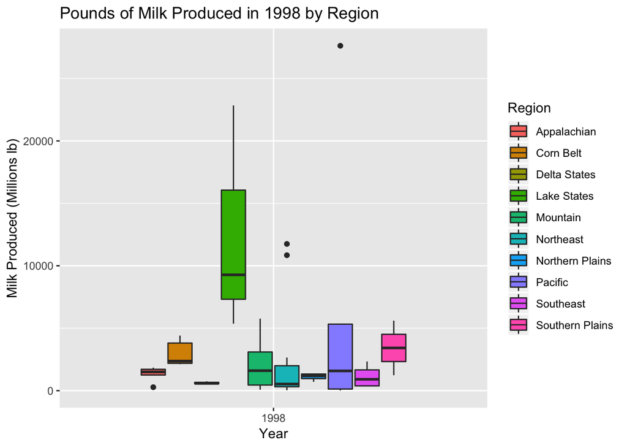

```r
milk1998 <- milk %>%
  filter(year == 1998)

ggplot(data = milk1998, aes(x = as.factor(year), y = milk_million, fill = region)) +  geom_boxplot() +
  ggtitle('Pounds of Milk Produced in 1998 by Region') +
  scale_fill_discrete(name = 'Region') +
  xlab('Year') +
  ylab('Milk Produced (Millions lb)')
```

#### Report

```r
milk1998 %>%
  filter(year == 1998) %>%
  summarise(avg_milk_produced = mean(milk_million),
            median_milk_produced = median(milk_million))%>%
  arrange(desc(avg_milk_produced))
```

```
##   avg_milk_produced median_milk_produced
## 1           3145.22               1411.5
```

```r
arrange(milk1998, desc(milk_million))%>%
  top_n(1)
```

```
##    region      state year milk_produced milk_million
## 1 Pacific California 1998     2.762e+10        27620
```

```r
leastmilk <- milk1998 %>%
  mutate(milkrank = -milk_million) %>%
  arrange(-milk_million)

top_n(leastmilk,1)%>%
  select(region, state, year, milk_produced, milk_million)
```

```
##    region  state year milk_produced milk_million
## 1 Pacific Alaska 1998       1.4e+07           14
```

### Jason Giblin

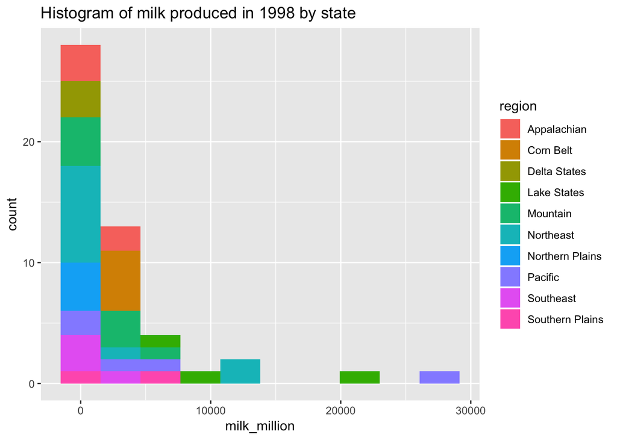

```r
milk1998 <- milk %>%
  filter(year == 1998)

ggplot(data= milk1998, aes(milk_million, fill = region), position = "fill")+
  geom_histogram(bins = 10)+
  ggtitle('Histogram of milk produced in 1998 by state')
```

#### Report

```r
milk1998 %>%
  summarise(avg_milk_produced = mean(milk_million), median_milk_produced = median(milk_million))%>%
  arrange(desc(avg_milk_produced))
```

```
##   avg_milk_produced median_milk_produced
## 1           3145.22               1411.5
```

```r
arrange(milk1998, desc(milk_million)) %>%
   top_n(1)
```

```
##    region      state year milk_produced milk_million
## 1 Pacific California 1998     2.762e+10        27620
```

### Tiger Su

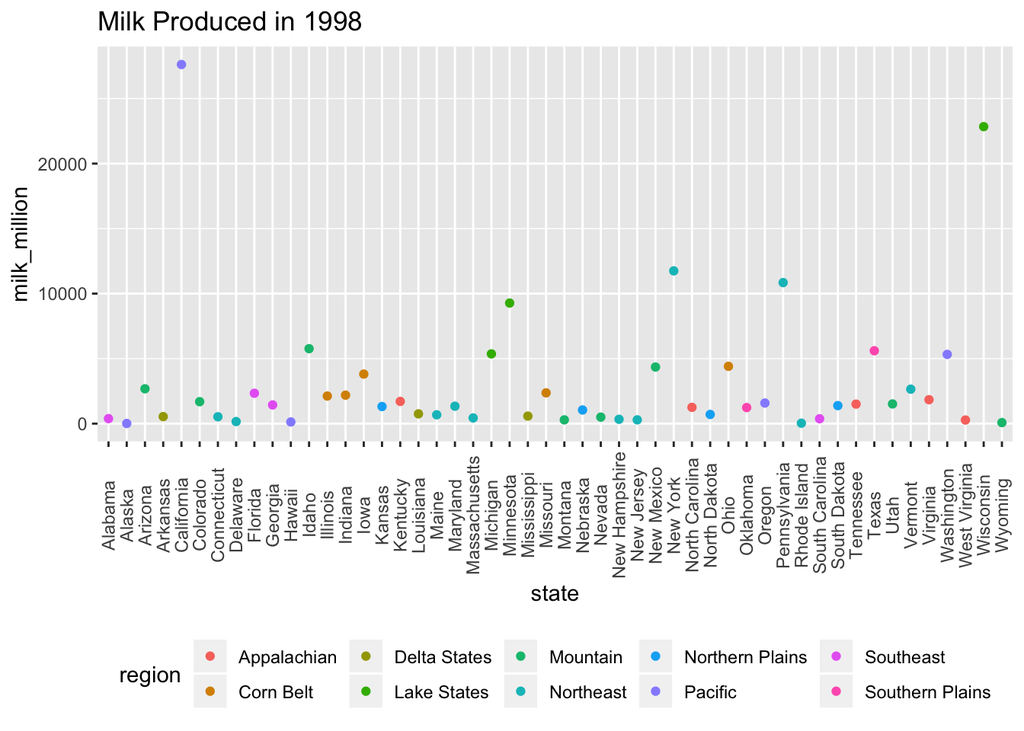

```r
milk1998<- milk%>%

  filter(year==1998)

ggplot(data = milk1998)+

  geom_point(aes(x=state, y=milk_million,color=region))+

  theme(legend.position = "bottom")+

  theme(axis.text.x = element_text(angle = 90, hjust = 0.5, vjust = 0.5))+

  ggtitle('Milk Produced in 1998')
```

#### Report

```r
milk1998%>%

summarise(Average_Milk_Produced_1998=mean(milk_million))
```

```
##   Average_Milk_Produced_1998
## 1                    3145.22
```

```r
milk1998%>%

summarise(Median_of_Milk_Produced_1998=median(milk_million))
```

```
##   Median_of_Milk_Produced_1998
## 1                       1411.5
```

```r
milk1998%>%

arrange(desc(milk_million))%>%

  slice(1)
```

```
##    region      state year milk_produced milk_million
## 1 Pacific California 1998     2.762e+10        27620
```

```r
milk1998%>%

arrange(milk_million)%>%

  slice(1)
```

```
##    region  state year milk_produced milk_million
## 1 Pacific Alaska 1998       1.4e+07           14
```